# CIFAR100_

### Práctica 1: CIFAR 100

Intentar conseguir el mejor score (fine tuning) con el dataset CIFAR 100 (se puede utilizar arquitecturas no secuenciales). Hacer distintas predicciones con la red y plotear los resultados.

Comparar, con la función show_history, el performance de varias (<10) NN's con distintas neuronas y capas. Obtener las siguientes gráficas (longitud <20 la longitud sea 15 modelos):

- score(accouracy) vs Batch_size (con la arquitectura conseguida previamente)
- score vs nº neuronas(las nuronas se aumentan por la proporcion, las 100 primeras por 0,1) (con las capas de la arquitectura conseguida previamente)

Hacer la comparativa de scores (acc, recall, precision, f1, confusion matrix) entre los siguientes modelos:

- Random Forest
- Otro modelo a elegir de Machine Learning
- Una red neuronal

```python
# Cargamos las librerías y las importamos
import matplotlib.pyplot as plt
import numpy as np
from tensorflow.keras.datasets import mnist
from tensorflow.keras import layers, Input, regularizers
from tensorflow.keras.models import Model
from tensorflow.keras.preprocessing.image import ImageDataGenerator
from tensorflow.keras.optimizers import SGD, Adam
from tensorflow.keras.metrics import AUC
from tensorflow.keras.losses import SparseCategoricalCrossentropy, MSE, MAE
import PyQt5
from mpl_toolkits.mplot3d import Axes3D
import tensorflow as tf
from keras.layers import Conv2D, MaxPooling2D
from keras.layers import Dropout
from keras.layers import BatchNormalization
from keras.layers import Flatten
import warnings
warnings.filterwarnings("ignore")
import pandas as pd
from sklearn.metrics import confusion_matrix
import seaborn as sns
from tensorflow.keras.datasets import cifar100
import pandas as pd
```

```python
# Función para plotear el history mediante loss_value o accuracy respecto a el numero de epocas
def show_history(history, metrics=['accuracy']):
    """
    Visualize history
    :param history:
    :return:
    """

    # Plot history: Loss
    plt.plot(history.history['loss'])
    plt.plot(history.history['val_loss'])
    plt.title('Loss history')
    plt.ylabel('Loss value')
    plt.xlabel('No. epoch')
    plt.legend(['train', 'validation'], loc='upper left')
    plt.show()

    for metric in metrics:
        # Plot history:
        plt.plot(history.history[metric])
        plt.plot(history.history['val_' + metric])
        plt.title(metric + ' history')
        plt.ylabel(metric + ' value (%)')
        plt.xlabel('No. epoch')
        plt.legend(['train', 'validation'], loc='upper left')
        plt.show()
```

```python
# Separamos el data set
(X_train, y_train), (X_validation, y_validation) = cifar100.load_data()
X_train = X_train/255 # Normalizamos el x_train y el X_validation
X_validation = X_validation/255
```

```
Número de elementos en el dataset =  60000
```

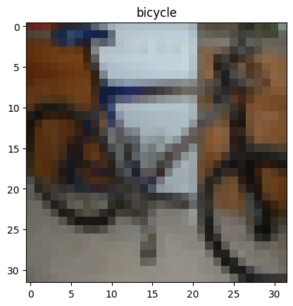

```python
# cargamos las etiquetas
labels = [
    'apple', 'aquarium_fish','baby','bear','beaver','bed','bee','beetle','bicycle','bottle','bowl',
    'boy','bridge', 'bus','butterfly','camel','can','castle','caterpillar','cattle','chair','chimpanzee',
    'clock','cloud','cockroach','couch','crab','crocodile','cup','dinosaur','dolphin','elephant','flatfish',
    'forest','fox','girl','hamster','house','kangaroo','computer_keyboard','lamp','lawn_mower','leopard',
    'lion','lizard', 'lobster','man', 'maple_tree', 'motorcycle', 'mountain', 'mouse', 'mushroom', 'oak_tree',
    'orange', 'orchid', 'otter', 'palm_tree', 'pear', 'pickup_truck', 'pine_tree', 'plain', 'plate', 'poppy',
    'porcupine','possum','rabbit','raccoon','ray','road','rocket','rose','sea','seal','shark','shrew','skunk',
    'skyscraper','snail','snake','spider','squirrel','streetcar', 'sunflower','sweet_pepper', 'table', 'tank',
    'telephone','television','tiger','tractor','train','trout','tulip','turtle','wardrobe',
    'whale','willow_tree','wolf','woman','worm']

print('Número de elementos en el dataset = ',X_train.shape[0]+X_validation.shape[0])
plt.title(labels[int(y_train[30])])
plt.imshow(X_train[30])
plt.show()
```

## Test 1

Primer testeo de la muestra utlizamos las funciones de activacion sigmoid, para las tres primeras capas de forma decreciente de mil hasta cien nueronas siendo la función del output softmax

```python
# capas de la red
input = Input(shape=(32,32,3))
input_flat = layers.Flatten()(input)
layer = layers.Dense(units=1000, activation='sigmoid')(input_flat)
layer = layers.Dense(units=500, activation='sigmoid')(layer)
layer = layers.Dense(units=200, activation='sigmoid')(layer)
output = layers.Dense(units=100, activation='softmax')(layer)

# creamos el modelo
model = Model(inputs=input, outputs=output)
print(model.summary())

# optimizador
optimizer = SGD(learning_rate=0.01)

# función loss
loss = SparseCategoricalCrossentropy(from_logits=False)

# métrica
metrics = ['accuracy']

# compilamos el modelo
model.compile(optimizer=optimizer, loss=loss, metrics=metrics)
```

```
Model: "model"
_________________________________________________________________
 Layer (type)                Output Shape              Param #
=================================================================
 input_1 (InputLayer)        [(None, 32, 32, 3)]       0

 flatten (Flatten)           (None, 3072)              0

 dense (Dense)               (None, 1000)              3073000

 dense_1 (Dense)             (None, 500)               500500

 dense_2 (Dense)             (None, 200)               100200

 dense_3 (Dense)             (None, 100)               20100

=================================================================
Total params: 3,693,800
Trainable params: 3,693,800
Non-trainable params: 0
_________________________________________________________________
None
```

```python
history = model.fit(x = X_train, y = y_train, batch_size = 30, epochs = 10,
                           validation_data = (X_validation, y_validation))
```

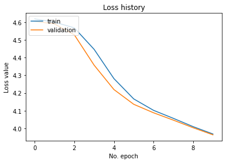

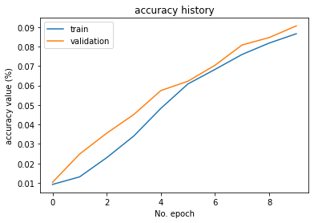

```python
show_history(history)
```

## TEST 2

Segundo testeo creamos un nuevo modelo de testeo, he introducimos una nueva capa, como función de activación utilizamos relu, que es la mas fiable en este tipo de redes, como output seguimos utilizando softmax que sirve para suavizar el modelo.

```python
# capas de la red
input = Input(shape=(32,32,3))
input_flat = layers.Flatten()(input)
layer = layers.Dense(units=1000, activation='relu')(input_flat)
layer = layers.Dense(units=750, activation='relu')(layer)
layer = layers.Dense(units=500, activation='relu')(layer)
layer = layers.Dense(units=250, activation='relu')(layer)
output = layers.Dense(units=100, activation='softmax')(layer)

# creamos el modelo
model_2 = Model(inputs=input, outputs=output)
print(model.summary())

# optimizador
optimizer = SGD(learning_rate=0.01)

# función loss
loss = SparseCategoricalCrossentropy(from_logits=False)

# métrica
metrics = ['accuracy']

# compilamos el modelo
model_2.compile(optimizer=optimizer, loss=loss, metrics=metrics)
```

```
Model: "model"
_________________________________________________________________
 Layer (type)                Output Shape              Param #
=================================================================
 input_1 (InputLayer)        [(None, 32, 32, 3)]       0

 flatten (Flatten)           (None, 3072)              0

 dense (Dense)               (None, 1000)              3073000

 dense_1 (Dense)             (None, 500)               500500

 dense_2 (Dense)             (None, 200)               100200

 dense_3 (Dense)             (None, 100)               20100

=================================================================
Total params: 3,693,800
Trainable params: 3,693,800
Non-trainable params: 0
_________________________________________________________________
None
```

```python
history2 = model_2.fit(x = X_train, y = y_train, batch_size = 30, epochs = 10,
                           validation_data = (X_validation, y_validation))
```

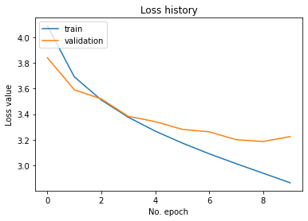

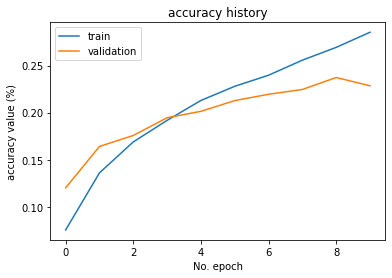

```python
show_history(history2)
```

## TEST 3

Mismo testeo que el anterior, pero reducimos una capa y notablemente el número de neuronas que utilizamos en cada capa. como función de optimización utilizamos adam

```python
# capas de la red
input = Input(shape=(32,32,3))
input_flat = layers.Flatten()(input)
layer = layers.Dense(units=500, activation='relu')(input_flat)
layer = layers.Dense(units=300, activation='relu')(layer)
layer = layers.Dense(units=250, activation='relu')(layer)
output = layers.Dense(units=100, activation='softmax')(layer)

# creamos el modelo
model_3 = Model(inputs=input, outputs=output)
print(model.summary())

# función loss
loss = SparseCategoricalCrossentropy(from_logits=False)

# métrica
metrics = ['accuracy']

# compilamos el modelo
model_3.compile(optimizer='Adam', loss=loss, metrics=metrics)
```

```
Model: "model"
_________________________________________________________________
 Layer (type)                Output Shape              Param #
=================================================================
 input_1 (InputLayer)        [(None, 32, 32, 3)]       0

 flatten (Flatten)           (None, 3072)              0

 dense (Dense)               (None, 1000)              3073000

 dense_1 (Dense)             (None, 500)               500500

 dense_2 (Dense)             (None, 200)               100200

 dense_3 (Dense)             (None, 100)               20100

=================================================================
Total params: 3,693,800
Trainable params: 3,693,800
Non-trainable params: 0
_________________________________________________________________
None
```

```python
history3 = model_3.fit(x = X_train, y = y_train, batch_size = 30, epochs = 10,
                           validation_data = (X_validation, y_validation))
```

```python
show_history(history3)
```

[output not shown]

## TEST 4

Utilizamos las mismas funciones de activaciones que antes pero añadimos más neuronas y seguimos utilizando como el optimiador Adam.

```python
# capas de la red
input = Input(shape=(32,32,3))
input_flat = layers.Flatten()(input)
layer = layers.Dense(units=1000, activation='relu')(input_flat)
layer = layers.Dense(units=750, activation='relu')(layer)
layer = layers.Dense(units=500, activation='relu')(layer)
layer = layers.Dense(units=250, activation='relu')(layer)
output = layers.Dense(units=100, activation='softmax')(layer)

# creamos el modelo
model_4 = Model(inputs=input, outputs=output)
print(model.summary())



# función loss
loss = SparseCategoricalCrossentropy(from_logits=False)

# métrica
metrics = ['accuracy']

# compilamos el modelo
model_4.compile(optimizer='Adam', loss=loss, metrics=metrics)
```

```
Model: "model"
_________________________________________________________________
 Layer (type)                Output Shape              Param #
=================================================================
 input_1 (InputLayer)        [(None, 32, 32, 3)]       0

 flatten (Flatten)           (None, 3072)              0

 dense (Dense)               (None, 1000)              3073000

 dense_1 (Dense)             (None, 500)               500500

 dense_2 (Dense)             (None, 200)               100200

 dense_3 (Dense)             (None, 100)               20100

=================================================================
Total params: 3,693,800
Trainable params: 3,693,800
Non-trainable params: 0
_________________________________________________________________
None
```

```python
history4 = model_4.fit(x = X_train, y = y_train, batch_size = 30, epochs = 10,
                           validation_data = (X_validation, y_validation))
```

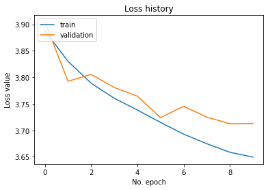

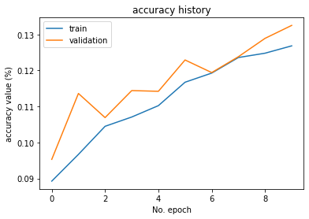

```python
show_history(history4)
```

## Test 5

Utilizamos un modelo convulucional de testeo utilizando la activacion de relu

```python
input = Input(shape=(32,32,3))
conv=Conv2D(10,(3,3),1,padding='same',activation='relu')(input)
#conv=BatchNormalization()(conv)
conv=Conv2D(20,(3,3),1,padding='same',activation='relu')(conv)

conv=MaxPooling2D(pool_size=2, strides=2)(conv)

conv=Dropout(.50)(conv)
conv=BatchNormalization()(conv)


conv=Flatten()(conv)
conv=Dropout(.5)(conv)
layer=layers.Dense(1000,activation='relu')(conv)

layer=Dropout(.5)(layer)
output=layers.Dense(100,activation='softmax')(layer)

# creamos el modelo
model_5 = Model(inputs=input, outputs=output)
print(model_5.summary())

# función loss
loss = SparseCategoricalCrossentropy(from_logits=False)

# métrica
metrics = ['accuracy']
model_5._name='model_5'
# compilamos el modelo
model_5.compile(optimizer= 'adam', loss=loss, metrics=metrics)
```

```
Model: "model_6"
_________________________________________________________________
 Layer (type)                Output Shape              Param #
=================================================================
 input_7 (InputLayer)        [(None, 32, 32, 3)]       0

 conv2d (Conv2D)             (None, 32, 32, 10)        280

 conv2d_1 (Conv2D)           (None, 32, 32, 20)        1820

 max_pooling2d (MaxPooling2D  (None, 16, 16, 20)       0
 )

 dropout (Dropout)           (None, 16, 16, 20)        0

 batch_normalization (BatchN  (None, 16, 16, 20)       80
 ormalization)

 flatten_6 (Flatten)         (None, 5120)              0

 dropout_1 (Dropout)         (None, 5120)              0

 dense_27 (Dense)            (None, 1000)              5121000

 dropout_2 (Dropout)         (None, 1000)              0

 dense_28 (Dense)            (None, 100)               100100

=================================================================
Total params: 5,223,280
Trainable params: 5,223,240
Non-trainable params: 40
_________________________________________________________________
None
```

```python
history_5 = model_5.fit(x=X_train, y=y_train, batch_size=30, epochs=10,
                    validation_data=(X_validation, y_validation))
```

[figure not shown]

[figure not shown]

```python
show_history(history_5)
```

## TEST 6

Utilizamos más neuronas y mismas funciones de activación, pero añadimos más capas y más neuronas, volviendo al optimizador SGD.

```python
# capas de la red
input = Input(shape=(32,32,3))
input_flat = layers.Flatten()(input)
layer = layers.Dense(units=1000, activation='relu')(input_flat)
layer = layers.Dense(units=800, activation='relu')(layer)
layer = layers.Dense(units=700, activation='relu')(layer)
layer = layers.Dense(units=500, activation='relu')(layer)
layer = layers.Dense(units=200, activation='relu')(layer)
output = layers.Dense(units=100, activation='softmax')(layer)

# creamos el modelo
model_6 = Model(inputs=input, outputs=output)
print(model.summary())

# optimizador
optimizer = SGD(learning_rate=0.01)

# función loss
loss = SparseCategoricalCrossentropy(from_logits=False)

# métrica
metrics = ['accuracy']

# compilamos el modelo
model_6.compile(optimizer=optimizer, loss=loss, metrics=metrics)
```

```
Model: "model"
_________________________________________________________________
 Layer (type)                Output Shape              Param #
=================================================================
 input_1 (InputLayer)        [(None, 32, 32, 3)]       0

 flatten (Flatten)           (None, 3072)              0

 dense (Dense)               (None, 1000)              3073000

 dense_1 (Dense)             (None, 500)               500500

 dense_2 (Dense)             (None, 200)               100200

 dense_3 (Dense)             (None, 100)               20100

=================================================================
Total params: 3,693,800
Trainable params: 3,693,800
Non-trainable params: 0
_________________________________________________________________
None
```

```python
history_6 = model_6.fit(x=X_train, y=y_train, batch_size=30, epochs=10,
                    validation_data=(X_validation, y_validation))
```

[figure not shown]

[figure not shown]

```python
show_history(history_6)
```

## TEST 7

Utilizamos como función de activación elu

```python
# capas de la red
input = Input(shape=(32,32,3))
input_flat = layers.Flatten()(input)
layer = layers.Dense(units=1000, activation='elu')(input_flat)
layer = layers.Dense(units=800, activation='elu')(layer)
layer = layers.Dense(units=700, activation='elu')(layer)
layer = layers.Dense(units=500, activation='elu')(layer)
layer = layers.Dense(units=200, activation='elu')(layer)
output = layers.Dense(units=100, activation='softmax')(layer)

# creamos el modelo
model_7 = Model(inputs=input, outputs=output)
print(model.summary())


# función loss
loss = SparseCategoricalCrossentropy(from_logits=False)

# métrica
metrics = ['accuracy']

# compilamos el modelo
model_7.compile(optimizer='Adam', loss=loss, metrics=metrics)
```

```
Model: "model"
_________________________________________________________________
 Layer (type)                Output Shape              Param #
=================================================================
 input_1 (InputLayer)        [(None, 32, 32, 3)]       0

 flatten (Flatten)           (None, 3072)              0

 dense (Dense)               (None, 1000)              3073000

 dense_1 (Dense)             (None, 500)               500500

 dense_2 (Dense)             (None, 200)               100200

 dense_3 (Dense)             (None, 100)               20100

=================================================================
Total params: 3,693,800
Trainable params: 3,693,800
Non-trainable params: 0
_________________________________________________________________
None
```

```python
history_7 = model_7.fit(x=X_train, y=y_train, batch_size=30, epochs=10,
                    validation_data=(X_validation, y_validation))
```

```python
show_history(history_7)
```

[output not shown]

## Testeo final

```python
# capas de la red
input = Input(shape=(32,32,3))
input_flat = layers.Flatten()(input)
layer = layers.Dense(units=1000, activation='relu')(input_flat)
layer = layers.Dense(units=750, activation='relu')(layer)
layer = layers.Dense(units=500, activation='relu')(layer)
layer = layers.Dense(units=250, activation='relu')(layer)
output = layers.Dense(units=100, activation='softmax')(layer)

# creamos el modelo
model_8 = Model(inputs=input, outputs=output)
print(model_8.summary())

# optimizador
optimizer = SGD(learning_rate=0.01)

# función loss
loss = SparseCategoricalCrossentropy(from_logits=False)

# métrica
metrics = ['accuracy']

# compilamos el modelo
model_8.compile(optimizer=optimizer, loss=loss, metrics=metrics)
```

```
Model: "model"
_________________________________________________________________
 Layer (type)                Output Shape              Param #
=================================================================
 input_1 (InputLayer)        [(None, 32, 32, 3)]       0

 flatten (Flatten)           (None, 3072)              0

 dense (Dense)               (None, 1000)              3073000

 dense_1 (Dense)             (None, 750)               750750

 dense_2 (Dense)             (None, 500)               375500

 dense_3 (Dense)             (None, 250)               125250

 dense_4 (Dense)             (None, 100)               25100

=================================================================
Total params: 4,349,600
Trainable params: 4,349,600
Non-trainable params: 0
_________________________________________________________________
```

[output not shown]

```
None
```

```python
history_8 = model_8.fit(x = X_train, y = y_train, batch_size = 64, epochs = 20,
                           validation_data = (X_validation, y_validation))
```

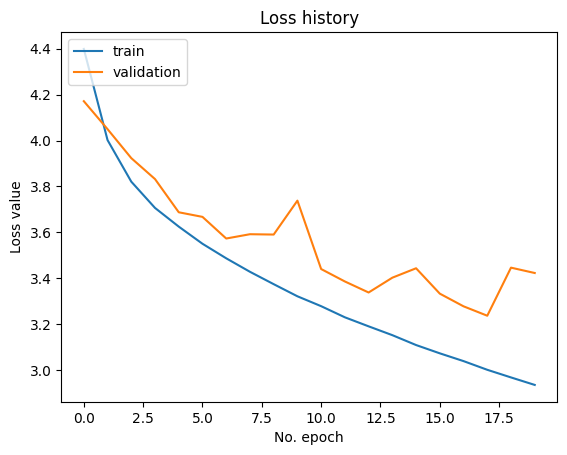

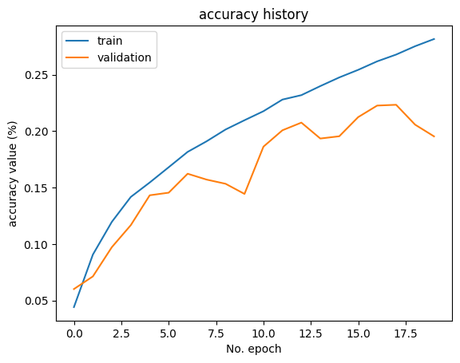

```python
show_history(history_8)
```

Creamos una matriz de confusión porque tiene indicios de overfitting

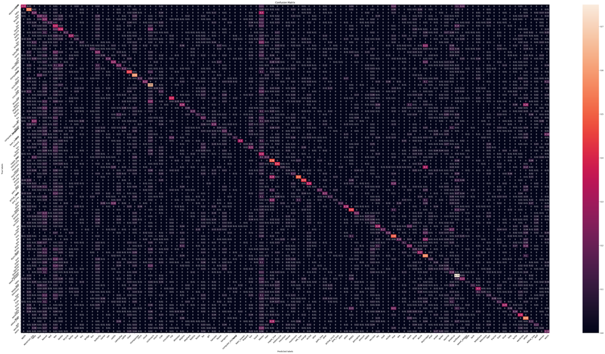

```python
y_pred = np.argmax(model_8.predict(X_validation), axis=-1)

plt.figure(figsize=(60, 30))
cm = confusion_matrix(y_true=y_validation, y_pred=y_pred, normalize='true', labels=range(100))
cm = np.around(cm, decimals=2)
ax = plt.subplot()
sns.heatmap(cm, annot=True, fmt='g', ax=ax)  # annot=True to annotate cells, ftm='g' to disable scientific notation
# labels, title and ticks
ax.set_xlabel('Predicted labels')
ax.set_ylabel('True labels')
ax.set_title('Confusion Matrix')
ax.xaxis.set_ticklabels(labels, rotation=45)
ax.yaxis.set_ticklabels(labels, rotation=45)
plt.show()
```

```python
from sklearn.metrics import classification_report

metricas_rf = classification_report(y_validation,y_pred,output_dict = True)
df=pd.DataFrame.from_dict((metricas_rf['weighted avg']), orient = 'index').transpose()
df['val_accuracy']=metricas_rf['accuracy']
df['Nombre']= 'Red Neuronal'
df_RN = df.set_index('Nombre')
df_RN
```

| Nombre | precision | recall | f1-score | support | val_accuracy |
| --- | --- | --- | --- | --- | --- |
| Red Neuronal | 0.253657 | 0.1954 | 0.185563 | 10000.0 | 0.1954 |

```python
input = Input(shape=(32,32,3))
input_flat = layers.Flatten()(input)
layer = layers.Dense(units=1000, activation='relu')(input_flat)
layer = layers.Dense(units=750, activation='relu')(layer)
layer = layers.Dense(units=500, activation='relu')(layer)
layer = layers.Dense(units=250, activation='relu')(layer)
output = layers.Dense(units=100, activation='softmax')(layer)

# creamos el modelo
model = Model(inputs=input, outputs=output)
print(model.summary())

# optimizador
optimizer = SGD(learning_rate=0.01)

# función loss
loss = SparseCategoricalCrossentropy(from_logits=False)

# métrica
metrics = ['accuracy']
# compilamos el modelo
model.compile(optimizer=optimizer, loss=loss, metrics=metrics)
# entrenamos

# Creación del for para poder plotear el batch_size por el valor del accuracy
list_batch_size = np.arange(5,555,25)

list_val_accuracy = []
for batch_size in list_batch_size:
  print(f'Training with batch size: {batch_size}')
  history = model.fit(x=X_train, y=y_train, batch_size=batch_size, epochs=10,
                            validation_data=(X_validation, y_validation))
  list_val_accuracy.append(history.history['val_accuracy'][-1])
```

```
Model: "model_2"
_________________________________________________________________
 Layer (type)                Output Shape              Param #
=================================================================
 input_3 (InputLayer)        [(None, 32, 32, 3)]       0

 flatten_2 (Flatten)         (None, 3072)              0

 dense_10 (Dense)            (None, 1000)              3073000

 dense_11 (Dense)            (None, 750)               750750

 dense_12 (Dense)            (None, 500)               375500

 dense_13 (Dense)            (None, 250)               125250

 dense_14 (Dense)            (None, 100)               25100

=================================================================
Total params: 4,349,600
Trainable params: 4,349,600
Non-trainable params: 0
_________________________________________________________________
None
Training with batch size: 5
Training with batch size: 30
Training with batch size: 55
Training with batch size: 80
Training with batch size: 105
Training with batch size: 130
Training with batch size: 155
Training with batch size: 180
Training with batch size: 205
Training with batch size: 230
Training with batch size: 255
Training with batch size: 280
Training with batch size: 305
Training with batch size: 330
Training with batch size: 355
Training with batch size: 380
Training with batch size: 405
Training with batch size: 430
Training with batch size: 455
Training with batch size: 480
Training with batch size: 505
Training with batch size: 530
```

Ploteamos el batch size por el validation accuracy

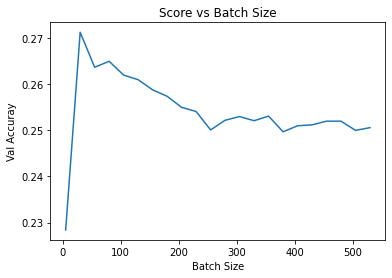

```python
plt.plot(list_batch_size, list_val_accuracy)
plt.xlabel('Batch Size')
plt.ylabel('Val Accurcay')
plt.title('Score vs Batch Size')
```

```python
# capas de la red
F = np.arange(1000,2500,150)
res = 40
list_val_accuracy = []
for initial_unit in F:

  # print(f'Training substracting: {res}')
  print(f'Training with these units:{initial_unit}, {initial_unit-res}, {initial_unit-(res*2)},  {initial_unit-(res*3)}')
  input = Input(shape=(32,32,3))
  input_flat = layers.Flatten()(input)
  layer = layers.Dense(units=initial_unit, activation='relu')(input_flat)
  layer = layers.Dense(units=initial_unit-res, activation='relu')(layer)
  layer = layers.Dense(units=initial_unit-(res*2), activation='relu')(layer)
  layer = layers.Dense(units=initial_unit-(res*3), activation='relu')(layer)
  output = layers.Dense(units=100, activation='softmax')(layer)

  # creamos el modelo
  model = Model(inputs=input, outputs=output)

  # optimizador
  optimizer = optimizer = SGD(learning_rate=0.01)

  # función loss
  loss = SparseCategoricalCrossentropy(from_logits=False)

  # métrica
  metrics = ['accuracy']

  # compilamos el modelo
  model.compile(optimizer=optimizer, loss=loss, metrics=metrics)

  # entrenamos
  history = model.fit(x=X_train, y=y_train, batch_size=250, epochs=10,
                              validation_data=(X_validation, y_validation))

  list_val_accuracy.append(history.history['val_accuracy'][-1])
```

```
Training with these units:1000, 960, 920,  880
Training with these units:1150, 1110, 1070,  1030
Training with these units:1300, 1260, 1220,  1180
Training with these units:1450, 1410, 1370,  1330
Training with these units:1600, 1560, 1520,  1480
Training with these units:1750, 1710, 1670,  1630
Training with these units:1900, 1860, 1820,  1780
Training with these units:2050, 2010, 1970,  1930
Training with these units:2200, 2160, 2120,  2080
Training with these units:2350, 2310, 2270,  2230
```

Ploteamos en número de neuronas por el validation accuracy

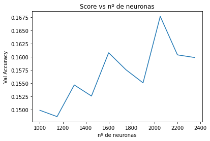

```python
plt.plot(f, list_val_accuracy)
plt.xlabel('nº de neuronas')
plt.ylabel('Val Accuracy')
plt.title('Score vs nº de neuronas')
```

## Utilizamos el Random forest para seguir con la práctica.

```python
from sklearn.ensemble import RandomForestClassifier
from sklearn.metrics import classification_report

clf = RandomForestClassifier(n_estimators=100) # utilizamos el random forest clasificador
```

```python
predict_forest = clf.fit(X_train.reshape((X_train.shape[0],-1)), y_train.reshape((-1,1)))
```

```python
predictions = clf.predict(X_validation.reshape((X_validation.shape[0],-1))) #predicción del modelo
```

```python
# utilizamos classication report para la predicción y la validación, con la finalidad de obtener los valores precision
# recall, f1 y val_accuracy
metricas_rf = classification_report(y_validation,predictions,output_dict = True)
df=pd.DataFrame.from_dict((metricas_rf['weighted avg']), orient = 'index').transpose()
df['val_accuracy']=metricas_rf['accuracy']
df['Nombre']= 'Random Forest'
df_RF = df.set_index('Nombre')
df_RF
```

| Nombre | precision | recall | f1-score | support | val_accuracy |
| --- | --- | --- | --- | --- | --- |
| Random Forest | 0.219093 | 0.2274 | 0.211462 | 10000.0 | 0.2274 |

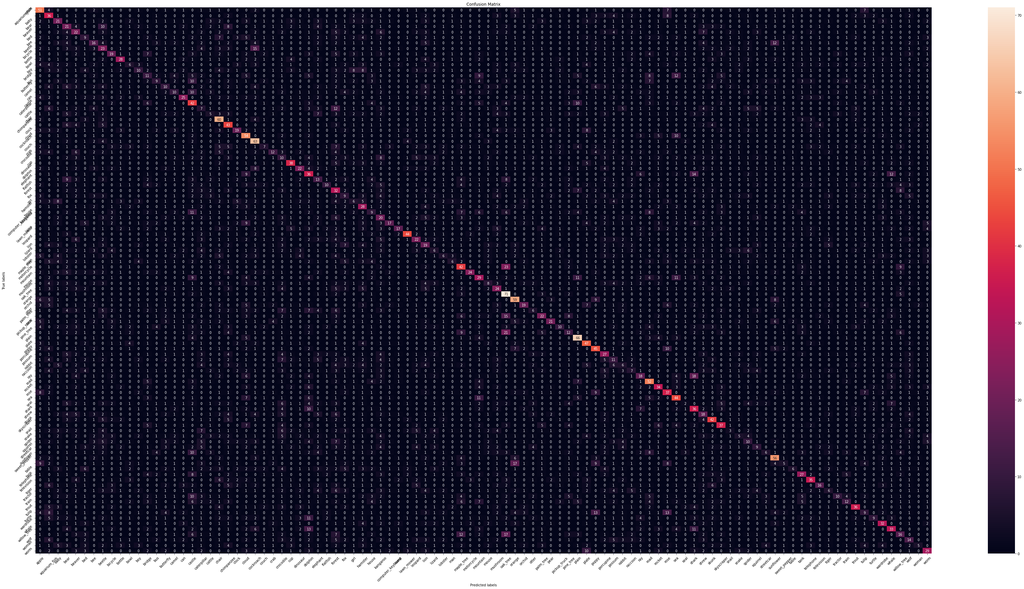

```python
# Creamos la matriz de confusión para las 100 variables y la ploteamos.
plt.figure(figsize=(60, 30))
cm = confusion_matrix(y_validation, predictions, labels = range(100))
cm = np.around(cm, decimals=2)
ax = plt.subplot()
sns.heatmap(cm, annot=True, fmt='g', ax=ax)  # annot=True to annotate cells, ftm='g' to disable scientific notation
# labels, title and ticks
ax.set_xlabel('Predicted labels')
ax.set_ylabel('True labels')
ax.set_title('Confusion Matrix')
ax.xaxis.set_ticklabels(labels, rotation=45)
ax.yaxis.set_ticklabels(labels, rotation=45)
plt.show()
```

## Naive Bayes

```python
from sklearn.naive_bayes import GaussianNB
clf1 = GaussianNB() # utilizamos naive bayes
```

```python
predict_Gaussian = clf1.fit(X_train.reshape((X_train.shape[0],-1)), y_train.reshape((-1,1)))
```

```python
predictions1 = clf1.predict(X_validation.reshape((X_validation.shape[0],-1)))
```

```python
metricas_rf = classification_report(y_validation,predictions1,output_dict = True)
df=pd.DataFrame.from_dict((metricas_rf['weighted avg']), orient = 'index').transpose()
df['val_accuracy']=metricas_rf['accuracy']
df['Nombre']= 'GaussianNB'
df_GNB = df.set_index('Nombre')
df_GNB
```

| Nombre | precision | recall | f1-score | support | val_accuracy |
| --- | --- | --- | --- | --- | --- |
| GaussianNB | 0.121434 | 0.1128 | 0.086876 | 10000.0 | 0.1128 |

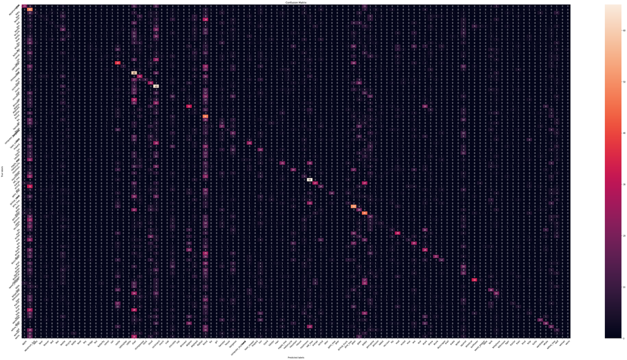

```python
plt.figure(figsize=(60, 30))
cm = confusion_matrix(y_validation, predictions1, labels = range(100))
cm = np.around(cm, decimals=2)
ax = plt.subplot()
sns.heatmap(cm, annot=True, fmt='g', ax=ax)  # annot=True to annotate cells, ftm='g' to disable scientific notation
# labels, title and ticks
ax.set_xlabel('Predicted labels')
ax.set_ylabel('True labels')
ax.set_title('Confusion Matrix')
ax.xaxis.set_ticklabels(labels, rotation=45)
ax.yaxis.set_ticklabels(labels, rotation=45)
plt.show()
```